# Tomasz Klonecki PD1

## 1. Wstęp

Dane pochodzą z Kaggle i dotyczą ofert mieszkaniowych w Nowym Jorku z serwisu Airbnb. W zadaniu porównam szybkość generowania wykresów w 3 poniższych bibliotekach:

- *graphics*
- *ggplot2*
- *lattice*

Każdy z wykresów w danym podpunkcie będę się starał wygenerować w miarę podobnie do pozostałych, tak żeby porównywać czas generowania jak najbardziej zbliżonych efektów.

## 2. Wykresy

### 2.1 Bar plot

Na początku porównam najbardziej podstawowy rodzaj wykresu jakim jest wykres słupkowy.

[figure not shown]

```r
nbhood_agg <- ny_data %>%
  group_by(neighbourhood_group) %>%
  summarize(avg_price = mean(price)) %>%
  arrange(desc(avg_price))

# graphics
  graphics::barplot(avg_price ~ sort(neighbourhood_group),
                  data = nbhood_agg,
                  col = heat.colors(12),
                  ylim = c(0,200),
                  main = 'Średnia cena mieszkania na Airbnb za dobę\n w różnych dzielnicach Nowego Jorku',
                  xlab = 'Dzielnica',
                  ylab = 'Średnia cena [$]')
```

[figure not shown]

```r
# ggplot2
ggplot(data = nbhood_agg, aes(x=sort(neighbourhood_group), y=avg_price)) +
  geom_bar(stat = 'identity', aes(fill = avg_price)) +
  theme_minimal() +
  scale_fill_gradient(low = "orange", high = "red")+
  theme(legend.title = element_blank(),
        legend.position = "none") +
  ggtitle('Średnia cena mieszkania na Airbnb za dobę\n w różnych dzielnicach Nowego Jorku') +
  labs(y='Średnia cena [$]', x = 'Dzielnica')
```

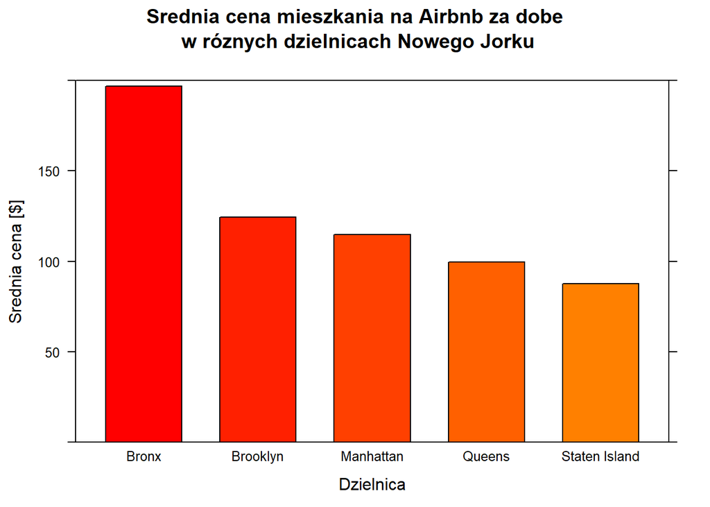

```r
# lattice
lattice::barchart(avg_price ~ sort(neighbourhood_group),
                  data = nbhood_agg,
                  col = heat.colors(12),
                  ylim = c(0,200),
                  main = 'Średnia cena mieszkania na Airbnb za dobę\n w różnych dzielnicach Nowego Jorku',
                  xlab = 'Dzielnica',
                  ylab = 'Średnia cena [$]')
```

Wykres wiolinowy poniżej prezentuje 100 różnych czasów generowania dla każdej biblioteki. Możemy zauważyć, że najszybszą biblioteką okazuje się *lattice*.

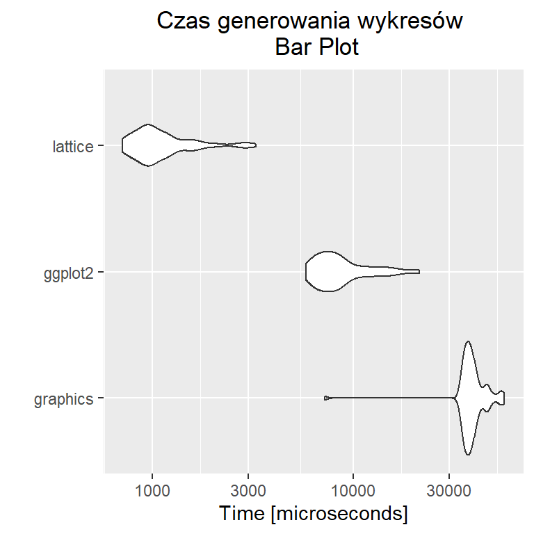

### 2.2 Box plot

Jednak żeby lepiej zrozumieć dane dotyczące cen za nocleg, warto zobaczyć je na wykresie pudełkowym

[figure not shown]

```r
# graphics
  graphics::boxplot(price ~ sort(neighbourhood_group),
                  data = ny_data,
                  col = heat.colors(12),
                  main = 'Cena mieszkania na Airbnb za dobę\n w różnych dzielnicach Nowego Jorku',
                  xlab = 'Dzielnica',
                  ylab = 'Cena [$]')
```

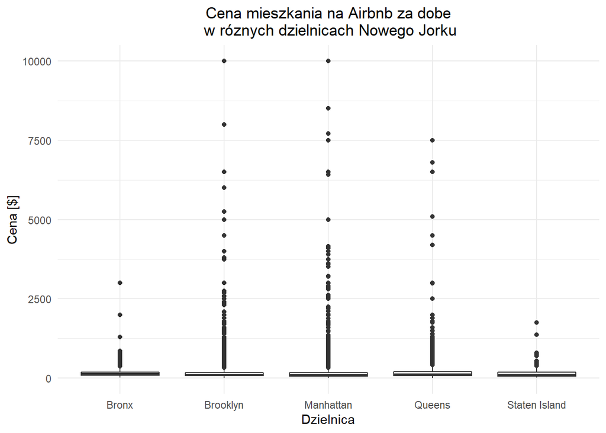

```r
# ggplot2
ggplot(data = ny_data, aes(x=sort(neighbourhood_group), y=price)) +
  geom_boxplot() +
  theme_minimal() +
  scale_fill_gradient(low = "orange", high = "red")+
  theme(legend.title = element_blank(),
        legend.position = "none",
        plot.title = element_text(hjust = 0.5)) +
  ggtitle('Cena mieszkania na Airbnb za dobę\n w różnych dzielnicach Nowego Jorku') +
  labs(y='Cena [$]', x = 'Dzielnica')
```

[figure not shown]

```r
# lattice
lattice::bwplot(price ~ sort(neighbourhood_group),
                  data = ny_data,
                  main = 'Cena mieszkania na Airbnb za dobę\n w różnych dzielnicach Nowego Jorku',
                  xlab = 'Dzielnica',
                  ylab = 'Cena [$]')
```

Wykres wiolinowy poniżej prezentuje 100 różnych czasów generowania dla każdej biblioteki. Tym razem okazuje się, że najszybszy w generowaniu wykresów pudełkowych jest ggplot. Dla tego typu wykresu zostawiłem domyślne parametrym, więc bardzo możliwe że w ogóle ggplot może być najszybszy. Sprawdzę to w późniejszych przykładach.

[figure not shown]

### 2.3 Scatter plot

Zbadam zależność lioniową ceny od ilości recenzji.

[figure not shown]

```r
# graphics
  graphics::plot(price ~ sort(number_of_reviews),
                  data = ny_data,
                  main = 'Cena mieszkania na Airbnb w zależności od ilości recenzji',
                  xlab = 'Ilość recenzji',
                  ylab = 'Cena [$]')
```

[figure not shown]

```r
# ggplot2
ggplot(data = ny_data, aes(x=sort(number_of_reviews), y=price)) +
  geom_point() +
  theme_minimal() +
  theme(legend.title = element_blank(),
        legend.position = "none",
        plot.title = element_text(hjust = 0.5)) +
  ggtitle('Cena mieszkania na Airbnb za dobę\n w różnych dzielnicach Nowego Jorku') +
  labs(y='Cena [$]', x = 'Ilość recenzji')
```

[figure not shown]

```r
# lattice
lattice::xyplot(price ~ number_of_reviews,
                  data = ny_data,
                  main = 'Cena mieszkania na Airbnb za dobę\n w różnych dzielnicach Nowego Jorku',
                  xlab = 'Ilość recenzji',
                  ylab = 'Cena [$]')
```

Wykres wiolinowy poniżej prezentuje 100 różnych czasów generowania dla każdej biblioteki. Tym razem również okazało się, że najszybszy w generowaniu wykresów punktowych jest *ggplot.*

[figure not shown]

### 2.4 Histogram

Zobaczmy jak wygląda rozkład minimalnej liczby nocy jakie trzeba zarezerwować.

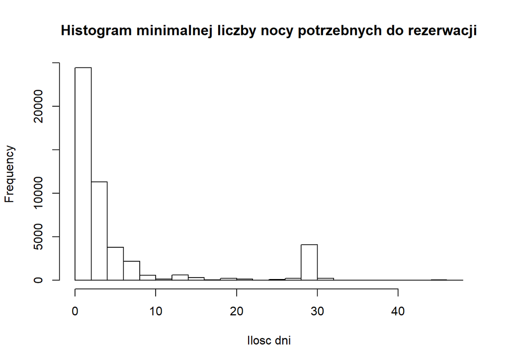

```r
# graphics
ny_data2 <- ny_data %>%
  filter(minimum_nights < 50)

ny_hist <- hist(pull(ny_data2['minimum_nights']), nclass = 30, plot = FALSE)
graphics::plot(ny_hist,
               main = 'Histogram minimalnej liczby nocy potrzebnych do rezerwacji',
               xlab = 'Ilość dni')
```

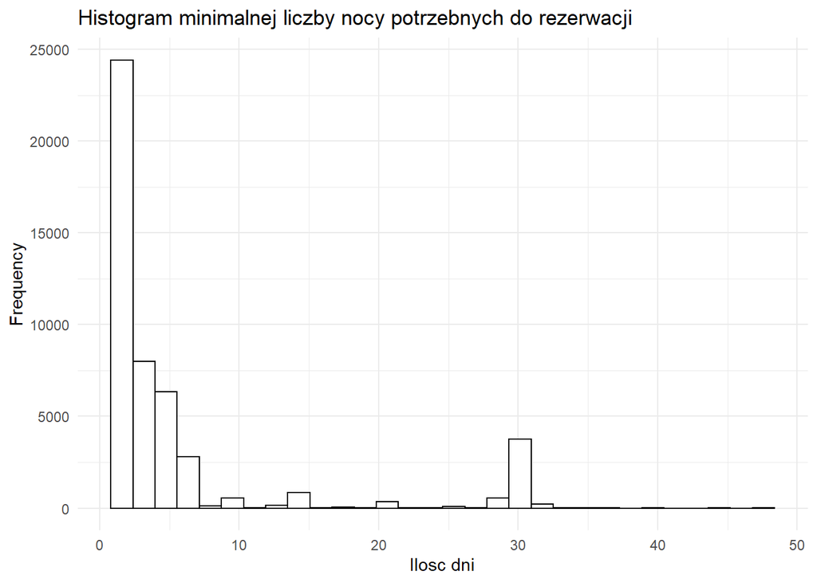

```r
# ggplot2
ggplot(ny_data2, aes(x=minimum_nights)) +
  geom_histogram(color="black", fill="white") +
  theme_minimal() +
  labs(y='Frequency', x = 'Ilość dni') +
  ggtitle('Histogram minimalnej liczby nocy potrzebnych do rezerwacji')
```

[figure not shown]

```r
# lattice
lattice::histogram( ~ minimum_nights,
                  data = ny_data2,
                  bins = 30,
                  main = 'Średnia cena mieszkania na Airbnb za dobę\n w różnych dzielnicach Nowego Jorku',
                  xlab = 'Dzielnica',
                  ylab = 'Średnia cena [$]')
```

Wykres wiolinowy poniżej prezentuje 100 różnych czasów generowania dla każdej biblioteki. Znów okazuje się, że ggplot i lattice są najszybsze.

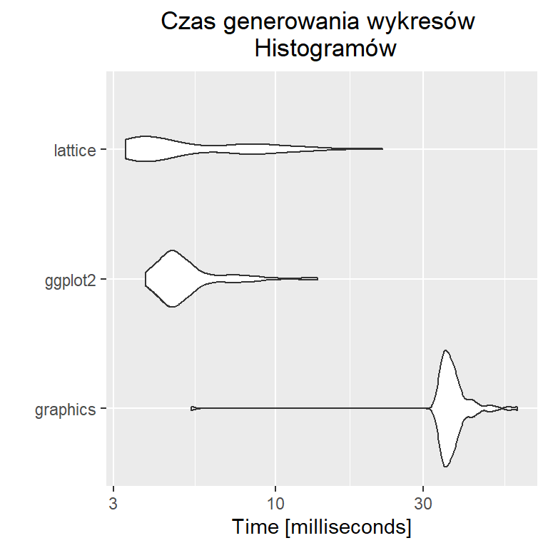

### 2.5 Bar plot 2

Na koniec sprawdzę jeszcze jak wygląda czas generowania bar plotów z domyślnymi ustawieniami. Dodam jedynie opis osi i tytuł w każdym wypadku.

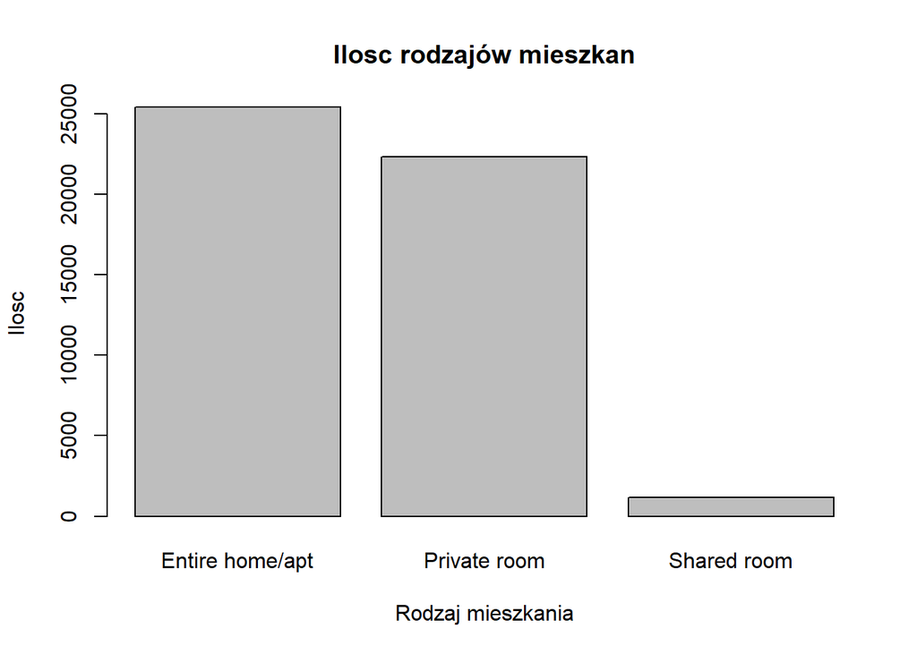

```r
room_agg <- ny_data %>%
  group_by(room_type) %>%
  summarize(cnt = n())

# graphics
  graphics::barplot(cnt ~ sort(room_type),
                  data = room_agg,
                  main = 'Ilość rodzajów mieszkań',
                  xlab = 'Rodzaj mieszkania',
                  ylab = 'Ilość')
```

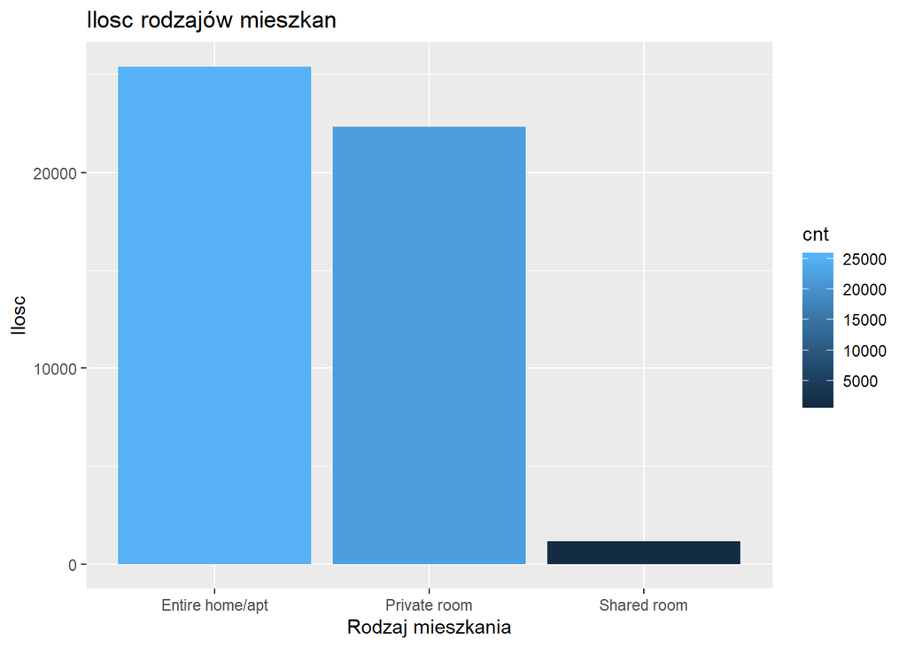

```r
# ggplot2
ggplot(data = room_agg, aes(x=sort(room_type), y=cnt)) +
  geom_bar(stat = 'identity', aes(fill = cnt)) +
  ggtitle('Ilość rodzajów mieszkań') +
  labs(y='Ilość', x = 'Rodzaj mieszkania')
```

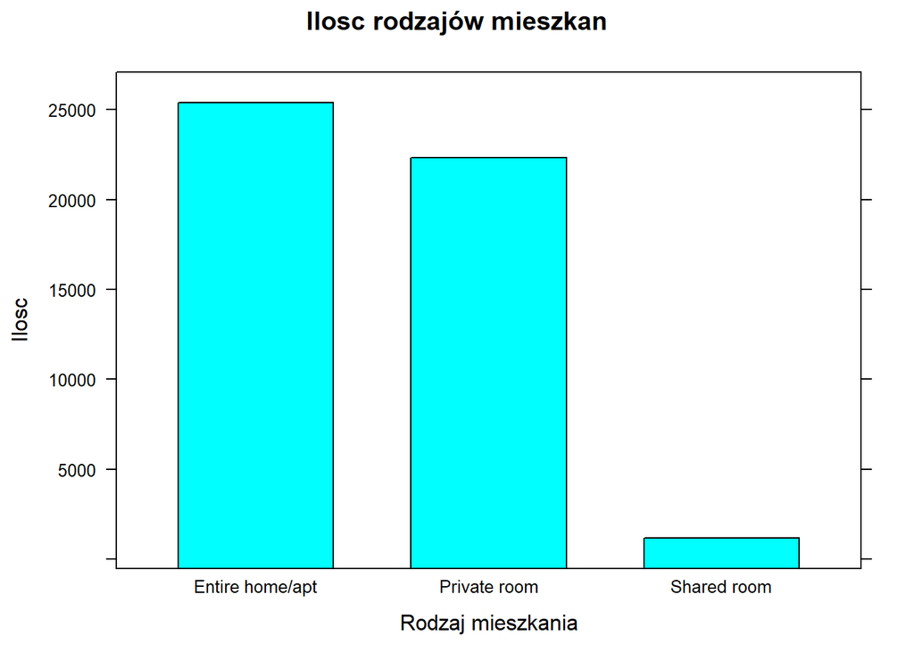

```r
# lattice
lattice::barchart(cnt ~ sort(room_type),
                  data = room_agg,
                  main = 'Ilość rodzajów mieszkań',
                  xlab = 'Rodzaj mieszkania',
                  ylab = 'Ilość')
```

Wykres wiolinowy poniżej prezentuje 100 różnych czasów generowania dla każdej biblioteki. Możemy zauważyć, że najszybszą biblioteką przy domyślnych parametrach pozostaje *lattice*..

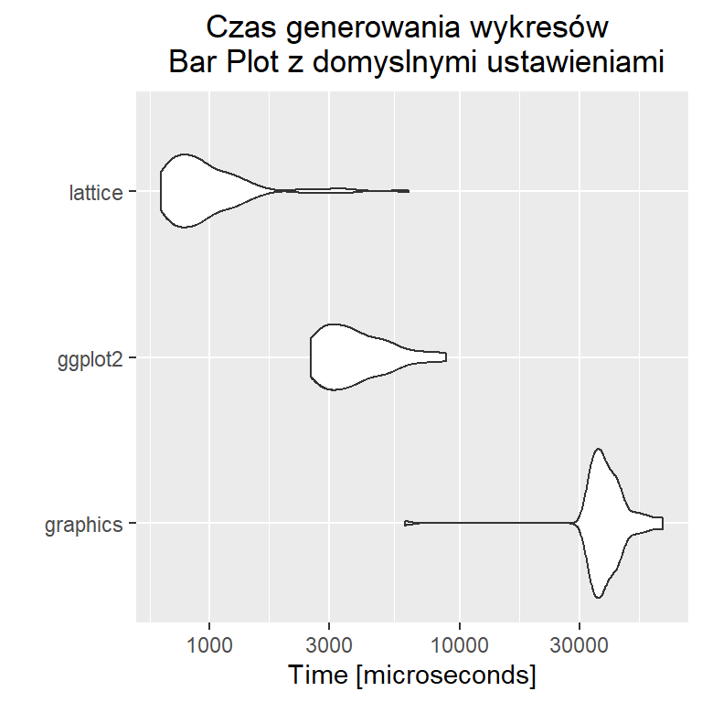

## 3. Podsumowanie

Bazując na wynikach wszystkich symulacji jestem w stanie stwierdzić że najszybszym pakietem do generowania wykresów jest *lattice* i *ggplot2*. W zależności od rodzaju wykresu jeden i drugi pakiet osiąga podobne rezultaty. Najgorsze ze wszystkich czasów uzyskał pakiet *graphics*, zawsze jest przynajmniej dwa razy wolniejszy od pozostałych.

Poniżej zamieszczam wykres zawierający wyniki wszystkich eksperymetnów.

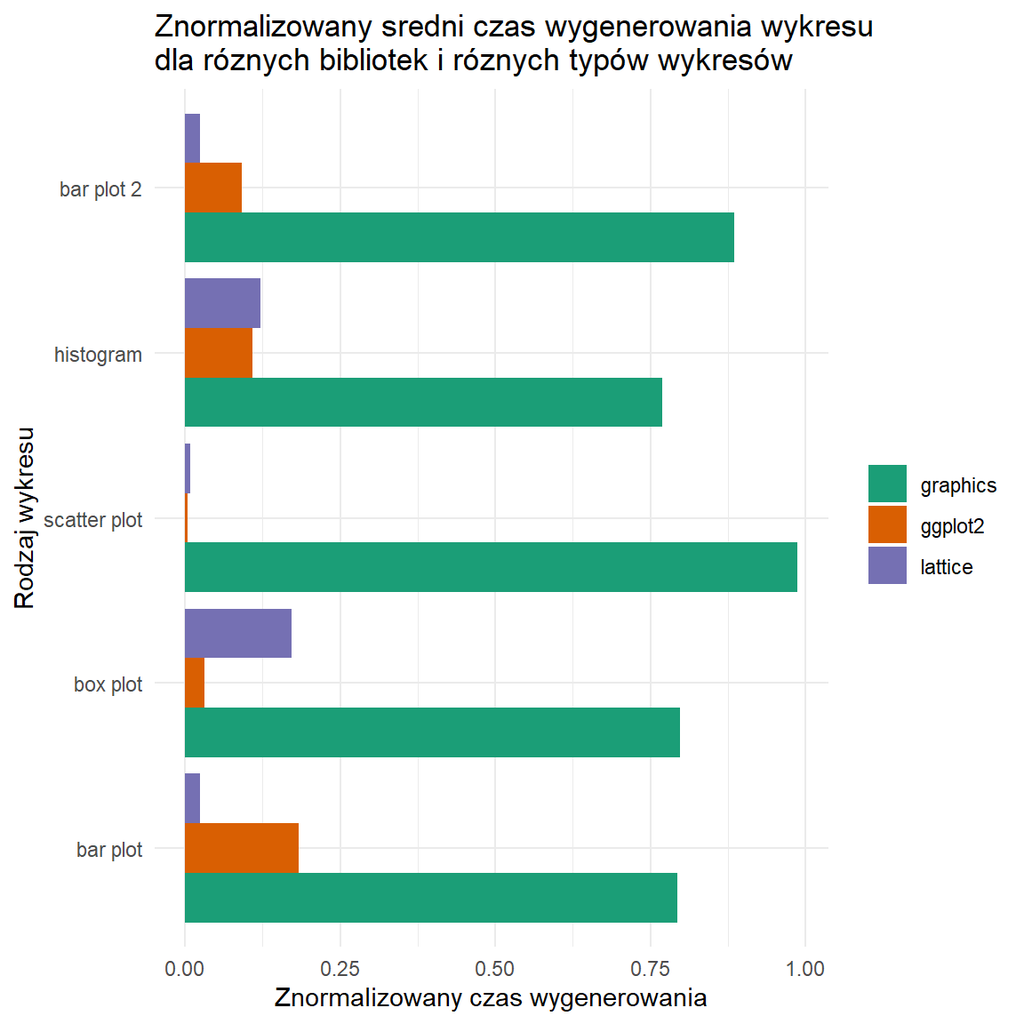